# Bank Churn Prediction

by Michele Casalgrandi

# Background

Customer churn is a concern for all businesses that provide financial services. In this case, a bank wants to be able to identify customers at risk of leaving and joining another service provider.

# Objective

Given a bank customer predict whether the customer will leave or not.

# Data Dictionary

- CustomerId: Unique ID which is assigned to each customer
- Surname: Last name of the customer
- CreditScore: It defines the credit history of the customer.
- Geography: A customer’s location
- Gender: It defines the Gender of the customer
- Age: Age of the customer
- Tenure: Number of years for which the customer has been with the bank
- NumOfProducts: It refers to the number of products that a customer has purchased through the bank.
- Balance: Account balance
- HasCrCard: It is a categorical variable that decides whether the customer has a credit card or not.
- EstimatedSalary: Estimated salary
- isActiveMember: It is a categorical variable that decides whether the customer is an active member of the bank or not ( Active member in the sense, using bank products regularly, making transactions, etc )
- Exited: It is a categorical variable that decides whether the customer left the bank within six months or not. It can take two values:  
  0=No ( Customer did not leave the bank )  
  1=Yes ( Customer left the bank )

#### Import necessary libraries and load data

```python
# import libraries
import numpy as np
import pandas as pd
from sklearn import metrics, model_selection
import matplotlib.pyplot as plt
%matplotlib inline
import seaborn as sns

from tensorflow.keras import Sequential
from tensorflow.keras.layers import Dense
import tensorflow as tf

# oversample and undersample
from imblearn.over_sampling import SMOTE
from imblearn.under_sampling import RandomUnderSampler

random_seed = 1
np.random.seed(random_seed)
```

```python
data_file = 'bank.csv'
df = pd.read_csv(data_file)

# get shape
print(f"There are {df.shape[0]} rows and {df.shape[1]} columns in the data set.")
```

```
There are 10000 rows and 14 columns in the data set.
```

```python
# list columns
df.columns
```

```
Index(['RowNumber', 'CustomerId', 'Surname', 'CreditScore', 'Geography',
       'Gender', 'Age', 'Tenure', 'Balance', 'NumOfProducts', 'HasCrCard',
       'IsActiveMember', 'EstimatedSalary', 'Exited'],
      dtype='object')
```

```python
# check the data type of each column
df.dtypes
```

```
RowNumber            int64
CustomerId           int64
Surname             object
CreditScore          int64
Geography           object
Gender              object
Age                  int64
Tenure               int64
Balance            float64
NumOfProducts        int64
HasCrCard            int64
IsActiveMember       int64
EstimatedSalary    float64
Exited               int64
dtype: object
```

There three columns stored as object: 'Surname', 'Geography' and 'Gender'.

The remaining columns are stored as numeric.

However, 'HasCrCard', 'IsActiveMember' and 'Exited' are categorical.

```python
df.info()
```

```
<class 'pandas.core.frame.DataFrame'>
RangeIndex: 10000 entries, 0 to 9999
Data columns (total 14 columns):
 #   Column           Non-Null Count  Dtype
---  ------           --------------  -----
 0   RowNumber        10000 non-null  int64
 1   CustomerId       10000 non-null  int64
 2   Surname          10000 non-null  object
 3   CreditScore      10000 non-null  int64
 4   Geography        10000 non-null  object
 5   Gender           10000 non-null  object
 6   Age              10000 non-null  int64
 7   Tenure           10000 non-null  int64
 8   Balance          10000 non-null  float64
 9   NumOfProducts    10000 non-null  int64
 10  HasCrCard        10000 non-null  int64
 11  IsActiveMember   10000 non-null  int64
 12  EstimatedSalary  10000 non-null  float64
 13  Exited           10000 non-null  int64
dtypes: float64(2), int64(9), object(3)
memory usage: 1.1+ MB
```

There are no missing values.

```python
# check for duplicates
df.duplicated().sum()
```

```
0
```

There are no duplicates.

```python
# check unique values
df.nunique()
```

```
RowNumber          10000
CustomerId         10000
Surname             2932
CreditScore          460
Geography              3
Gender                 2
Age                   70
Tenure                11
Balance             6382
NumOfProducts          4
HasCrCard              2
IsActiveMember         2
EstimatedSalary     9999
Exited                 2
dtype: int64
```

```python
# view a sample of the data
df.sample(12)
```

|  | RowNumber | CustomerId | Surname | CreditScore | Geography | Gender | Age | Tenure | Balance | NumOfProducts | HasCrCard | IsActiveMember | EstimatedSalary | Exited |
| --- | --- | --- | --- | --- | --- | --- | --- | --- | --- | --- | --- | --- | --- | --- |
| 9953 | 9954 | 15655952 | Burke | 550 | France | Male | 47 | 2 | 0.000 | 2 | 1 | 1 | 97057.280 | 0 |
| 3850 | 3851 | 15775293 | Stephenson | 680 | France | Male | 34 | 3 | 143292.950 | 1 | 1 | 0 | 66526.010 | 0 |
| 4962 | 4963 | 15665088 | Gordon | 531 | France | Female | 42 | 2 | 0.000 | 2 | 0 | 1 | 90537.470 | 0 |
| 3886 | 3887 | 15720941 | Tien | 710 | Germany | Male | 34 | 8 | 147833.300 | 2 | 0 | 1 | 1561.580 | 0 |
| 5437 | 5438 | 15733476 | Gonzalez | 543 | Germany | Male | 30 | 6 | 73481.050 | 1 | 1 | 1 | 176692.650 | 0 |
| 8517 | 8518 | 15671800 | Robinson | 688 | France | Male | 20 | 8 | 137624.400 | 2 | 1 | 1 | 197582.790 | 0 |
| 2041 | 2042 | 15709846 | Yeh | 840 | France | Female | 39 | 1 | 94968.970 | 1 | 1 | 0 | 84487.620 | 0 |
| 1989 | 1990 | 15622454 | Zaitsev | 695 | Spain | Male | 28 | 0 | 96020.860 | 1 | 1 | 1 | 57992.490 | 0 |
| 1933 | 1934 | 15815560 | Bogle | 666 | Germany | Male | 74 | 7 | 105102.500 | 1 | 1 | 1 | 46172.470 | 0 |
| 9984 | 9985 | 15696175 | Echezonachukwu | 602 | Germany | Male | 35 | 7 | 90602.420 | 2 | 1 | 1 | 51695.410 | 0 |
| 8418 | 8419 | 15731026 | Han | 683 | Germany | Female | 39 | 2 | 100062.160 | 2 | 1 | 0 | 109201.430 | 0 |
| 2418 | 2419 | 15603914 | Arcuri | 614 | France | Male | 40 | 6 | 0.000 | 1 | 1 | 1 | 20339.790 | 1 |

Observations:

- `RowNumber` is same as index but offset by 1. This column doesn't add any value and will be dropped
- `CustomerId` is unique for all rows and has no predictive value.  
  It will be dropped.
- `Surname` has duplicates but none have same CustomerId, so they are distinct customers.  
  Surname having predictive value is extremely low, we will drop this column.

```python
target_class = 'Exited'

cols_to_drop = ['RowNumber', 'CustomerId', 'Surname']

# drop columns
bank = df.drop(columns=cols_to_drop, axis=1)
```

```python
bank.sample(12)
```

|  | CreditScore | Geography | Gender | Age | Tenure | Balance | NumOfProducts | HasCrCard | IsActiveMember | EstimatedSalary | Exited |
| --- | --- | --- | --- | --- | --- | --- | --- | --- | --- | --- | --- |
| 9203 | 773 | Spain | Male | 51 | 4 | 0.000 | 2 | 0 | 0 | 123587.830 | 1 |
| 7827 | 605 | France | Male | 41 | 10 | 0.000 | 2 | 0 | 1 | 97213.090 | 0 |
| 3620 | 773 | France | Male | 41 | 4 | 0.000 | 2 | 1 | 1 | 24924.920 | 0 |
| 5919 | 645 | Spain | Male | 49 | 8 | 0.000 | 2 | 1 | 0 | 162012.600 | 0 |
| 72 | 657 | Spain | Female | 37 | 0 | 163607.180 | 1 | 0 | 1 | 44203.550 | 0 |
| 4685 | 537 | Spain | Male | 42 | 1 | 190569.230 | 1 | 0 | 1 | 127154.800 | 0 |
| 8684 | 813 | Germany | Male | 27 | 6 | 111348.150 | 1 | 1 | 0 | 46422.460 | 0 |
| 943 | 675 | Germany | Female | 29 | 8 | 121326.420 | 1 | 1 | 0 | 133457.520 | 0 |
| 2055 | 469 | Germany | Male | 38 | 9 | 113599.420 | 1 | 0 | 0 | 11950.290 | 0 |
| 9021 | 655 | Germany | Female | 61 | 2 | 183997.700 | 2 | 1 | 1 | 161217.180 | 0 |
| 2489 | 714 | France | Male | 28 | 6 | 122724.370 | 1 | 1 | 1 | 67057.270 | 0 |
| 5118 | 721 | France | Male | 40 | 3 | 0.000 | 1 | 1 | 1 | 144874.670 | 0 |

It seems many records have 0.0 as balance.

```python
bank['Balance'][bank['Balance'] < 0.1].count()
```

```
3617
```

About 36% of customers have zero balance.

```python
# set numerical format for pandas
pd.set_option("display.float_format", lambda x: "%.3f" % x)

# list categorical stored as numeric
non_object_categ = ['HasCrCard','IsActiveMember','Exited']

# get numerical data statistics
bank.drop(columns=non_object_categ, axis=1).describe().T
```

|  | count | mean | std | min | 25% | 50% | 75% | max |
| --- | --- | --- | --- | --- | --- | --- | --- | --- |
| CreditScore | 10000.000 | 650.529 | 96.653 | 350.000 | 584.000 | 652.000 | 718.000 | 850.000 |
| Age | 10000.000 | 38.922 | 10.488 | 18.000 | 32.000 | 37.000 | 44.000 | 92.000 |
| Tenure | 10000.000 | 5.013 | 2.892 | 0.000 | 3.000 | 5.000 | 7.000 | 10.000 |
| Balance | 10000.000 | 76485.889 | 62397.405 | 0.000 | 0.000 | 97198.540 | 127644.240 | 250898.090 |
| NumOfProducts | 10000.000 | 1.530 | 0.582 | 1.000 | 1.000 | 1.000 | 2.000 | 4.000 |
| EstimatedSalary | 10000.000 | 100090.240 | 57510.493 | 11.580 | 51002.110 | 100193.915 | 149388.247 | 199992.480 |

#### Get value counts for categorical variables

```python
# Get categorical columns
cat_cols = bank.select_dtypes(include=['object']).columns.to_list()
print(cat_cols)

# Add categoricals stored as numeric.
cat_cols = cat_cols + non_object_categ
print(cat_cols)
```

```
['Geography', 'Gender']
['Geography', 'Gender', 'HasCrCard', 'IsActiveMember', 'Exited']
```

```python
# get value counts for each categorical column
for col in cat_cols:
    print(f"\n------------------\n{col}:")
    print(bank[col].value_counts())
```

```
------------------
Geography:
France     5014
Germany    2509
Spain      2477
Name: Geography, dtype: int64

------------------
Gender:
Male      5457
Female    4543
Name: Gender, dtype: int64

------------------
HasCrCard:
1    7055
0    2945
Name: HasCrCard, dtype: int64

------------------
IsActiveMember:
1    5151
0    4849
Name: IsActiveMember, dtype: int64

------------------
Exited:
0    7963
1    2037
Name: Exited, dtype: int64
```

### Univariate EDA

```python
# function takes a numerical column as the input and returns the boxplots
# and histograms for the variable.
def histogram_boxplot(feature, figsize=(15,15), bins = None):
    """ Boxplot and histogram combined
    feature: 1-d feature array
    figsize: size of fig (default (9,8))
    bins: number of bins (default None / auto)
    """
    f2, (ax_box2, ax_hist2) = plt.subplots(nrows = 2, # Number of rows of the subplot grid= 2
                                           sharex = True, # x-axis will be shared among all subplots
                                           gridspec_kw = {"height_ratios": (.25, .75)},
                                           figsize = figsize
                                           ) # creating the 2 subplots
    sns.boxplot(x=feature, ax=ax_box2, showmeans=True, color='violet') # boxplot will be created and a star will indicate the mean value of the column
    sns.histplot(feature, kde=False, ax=ax_hist2, bins=bins) if bins else sns.histplot(feature, kde=False, ax=ax_hist2) # For histogram
    ax_hist2.axvline(np.mean(feature), color='green', linestyle='--') # Add mean to the histogram
    ax_hist2.axvline(np.median(feature), color='black', linestyle='-') # Add median to the histogram
```

##### Plot numeric variables distributions

```python
numeric_cols = set(bank.columns.to_list()).difference(cat_cols)
print (numeric_cols)
for col in numeric_cols:
    print(f'histogram_plot(bank[{col}])')
```

```
{'NumOfProducts', 'Age', 'Balance', 'CreditScore', 'EstimatedSalary', 'Tenure'}
histogram_plot(bank[NumOfProducts])
histogram_plot(bank[Age])
histogram_plot(bank[Balance])
histogram_plot(bank[CreditScore])
histogram_plot(bank[EstimatedSalary])
histogram_plot(bank[Tenure])
```

##### Age

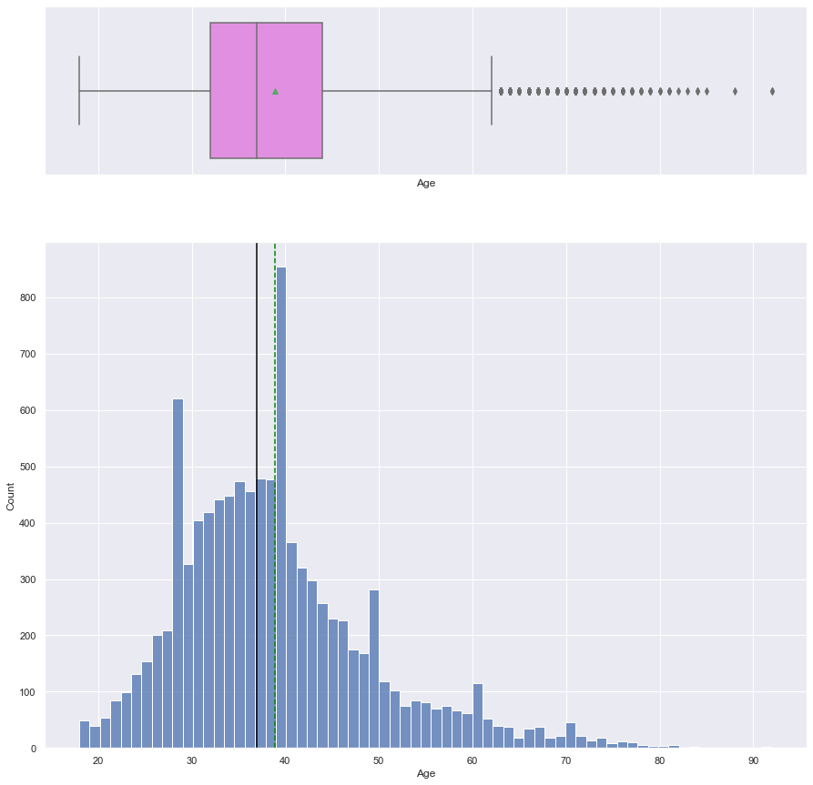

```python
histogram_boxplot(bank['Age'])
```

`Age` distribution is skewed to the right with many outlier and a few extreme outliers

```python
bank['Age'][bank['Age'] >= 70].value_counts(sort=False)
```

```
70    18
71    27
72    21
73    13
74    18
75     9
76    11
77    10
78     5
79     4
80     3
81     4
82     1
83     1
84     2
85     1
88     1
92     2
Name: Age, dtype: int64
```

We will drop rows with age > 77 (24 rows < 1%).

Not shown: dropping `Age` outliers improves models performance.

```python
bank.drop(index=bank[bank['Age'] > 77].index,inplace=True)
bank['Age'][bank['Age'] >= 70].value_counts(sort=False)
```

```
70    18
71    27
72    21
73    13
74    18
75     9
76    11
77    10
Name: Age, dtype: int64
```

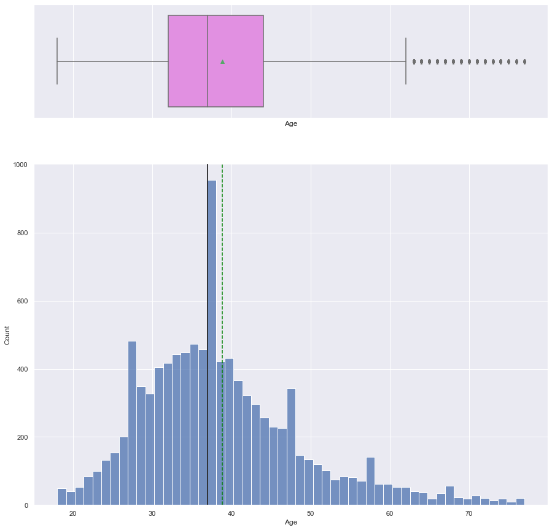

```python
histogram_boxplot(bank['Age'])
```

Distribution is still skewed to the right.

##### CreditScore

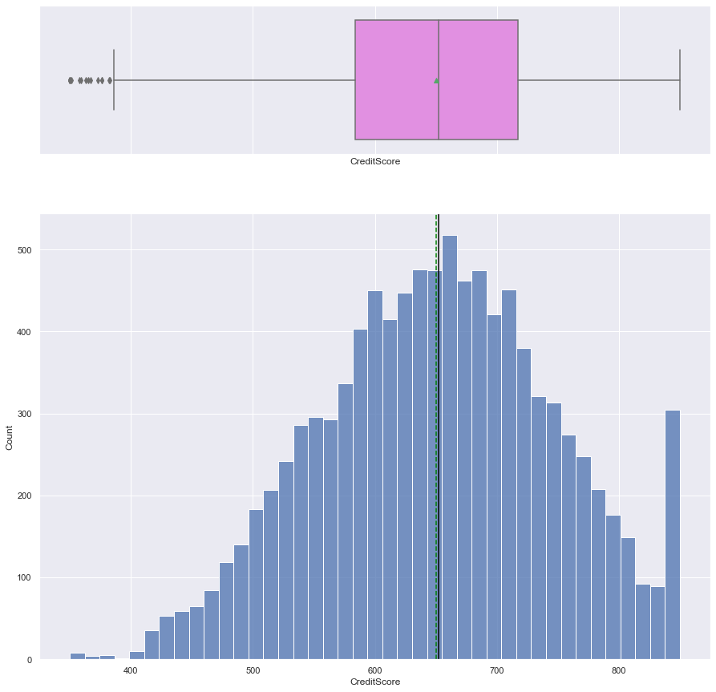

```python
histogram_boxplot(bank['CreditScore'])
```

`CreditScore` is almost normally distributed with a number of outliers to the left (< ~ 400) and a peak at 850 which is probably the maximum credit score.

##### Tenure

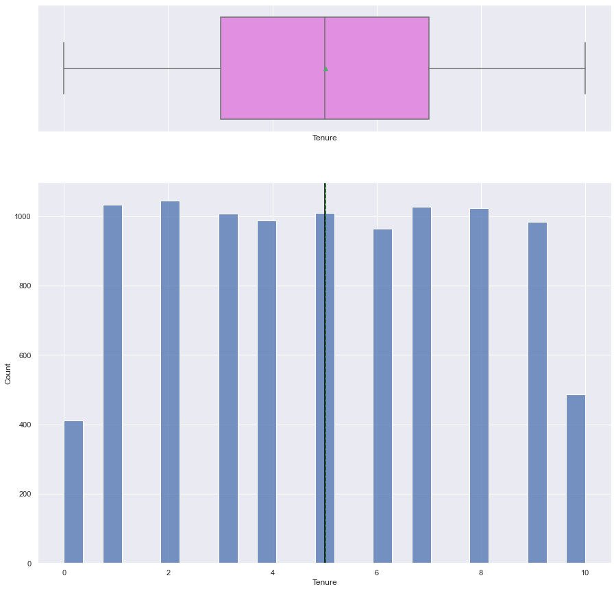

```python
histogram_boxplot(bank['Tenure'])
```

`Tenure` is almost uniformly distributed except for the extremes of the range (0 and 10) which are tapering off.

##### EstimatedSalary

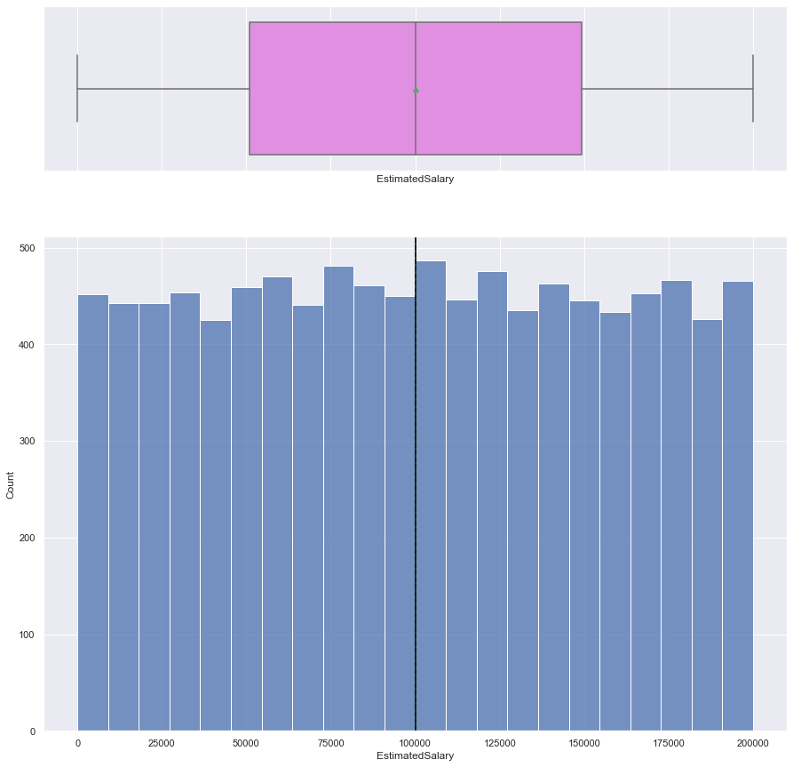

```python
histogram_boxplot(bank['EstimatedSalary'])
```

`EstimatedSalary` is uniformly distributed.

##### NumOfProducts

```python
bank['NumOfProducts'].value_counts()
```

```
1    5072
2    4578
3     266
4      60
Name: NumOfProducts, dtype: int64
```

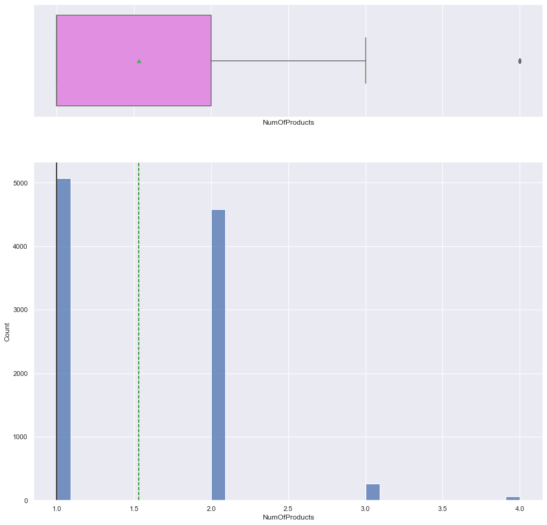

```python
histogram_boxplot(bank['NumOfProducts'])
```

`NumOfProducts` is discrete and skewed to the right. Most customers have either 1 or 2 products.

We will drop the outliers with more than 3 products (60 records < 1%).

Not shown: dropping outliers for `NumOfProducts` improves models performance.

```python
# drop outliers
bank.drop(index=bank[bank['NumOfProducts'] > 3].index, inplace=True)
```

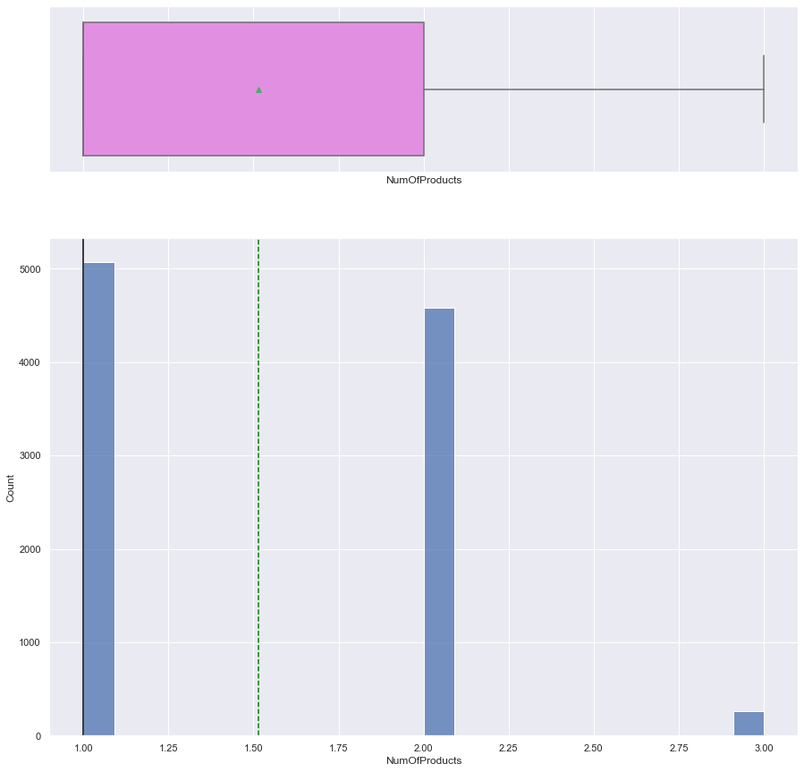

```python
histogram_boxplot(bank['NumOfProducts'])
```

##### Balance

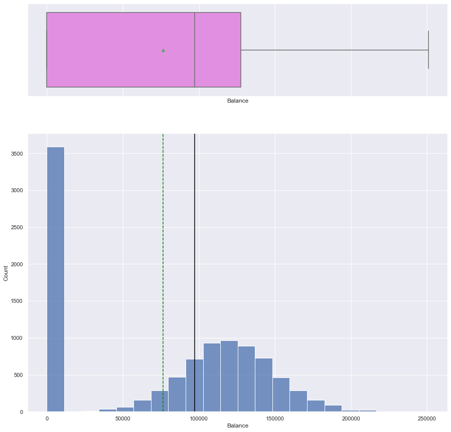

```python
histogram_boxplot(bank['Balance'])
```

`Balance` is almost normally distributed with the exception of a peak at 0 (36% of customers have zero balance).

Because of the skeweness of the data and the peak at zero, we will break it down into customers with zero balance (0) and customers with a positive balance (1).

Not shown: binning `Balance` improves models performance.

```python
bank['Balance'] = bank['Balance'].apply(lambda x: 0 if x < 1000 else 1)
```

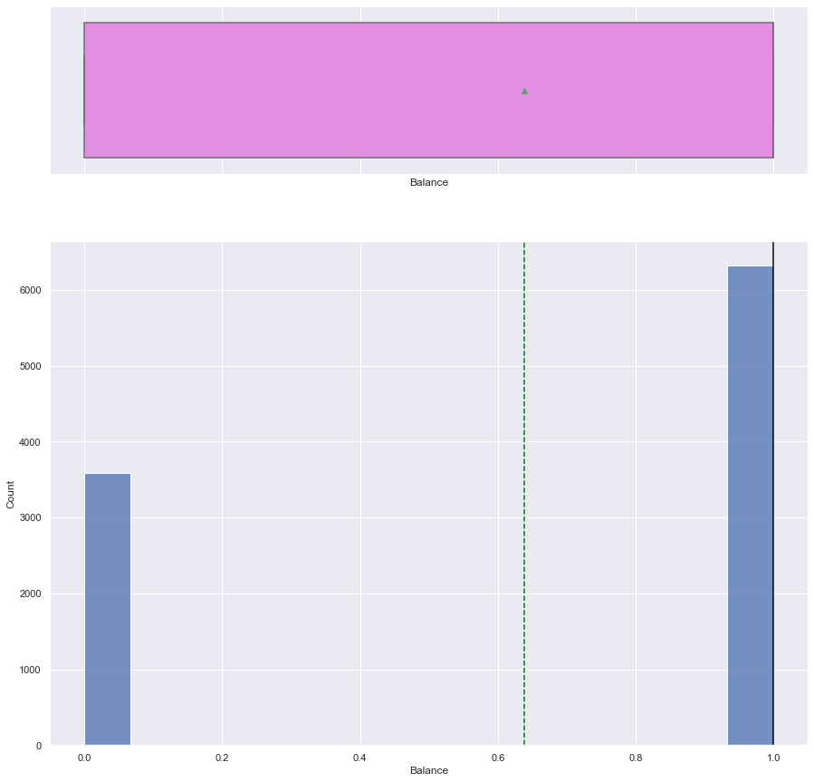

```python
histogram_boxplot(bank['Balance'])
```

##### Categorical variables univariate analysis

Define function to plot barplot with percentages.

```python
# define function to plot the counts and percentages
def perc_on_bar(z):
    '''
    plot a categorical variable using countplot and add percentages for each value
    z: categorical feature
    the function won't work if a column is passed in hue parameter
    '''

    total = len(z) # length of the column
    plt.figure(figsize=(15,5))
    #plt.xticks(rotation=45)
    ax = sns.countplot(x=z,palette='Paired')
    for p in ax.patches:
        percentage = '{:.1f}%'.format(100 * p.get_height()/total) # percentage of each class of the category
        x = p.get_x() + p.get_width() / 2 - 0.05 # width of the plot
        y = p.get_y() + p.get_height()           # hieght of the plot

        ax.annotate(percentage, (x, y), size = 12) # annotate the percentage
    plt.show() # show the plot
```

Note: no additional observations from bar plots for categorical variables in addition to what already covered above.

##### Geography

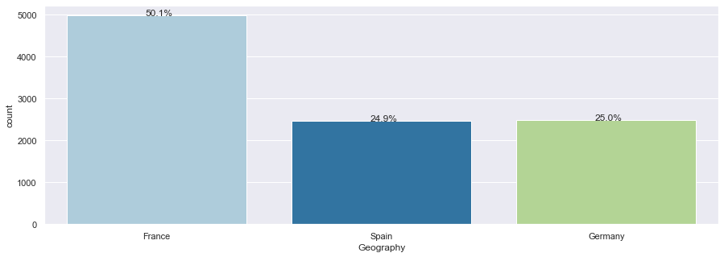

```python
perc_on_bar(bank["Geography"])
```

##### Gender

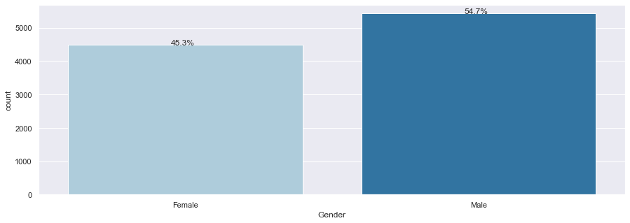

```python
perc_on_bar(bank["Gender"])
```

##### HasCrCard

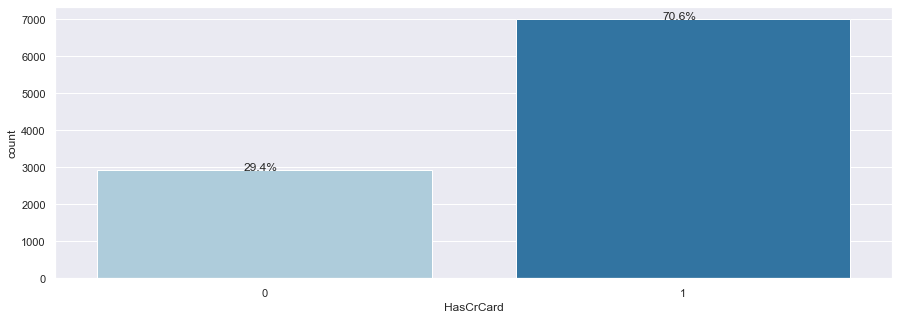

```python
perc_on_bar(bank["HasCrCard"])
```

##### IsActiveMember

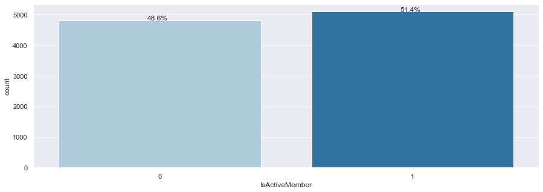

```python
perc_on_bar(bank["IsActiveMember"])
```

##### Exited

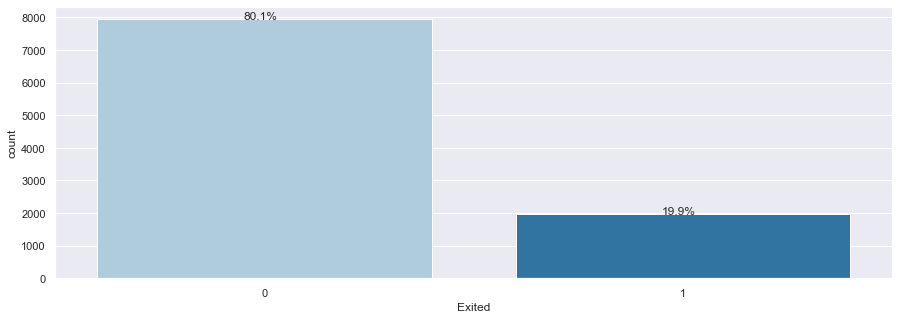

```python
perc_on_bar(bank["Exited"])
```

## By-Variate Analysis

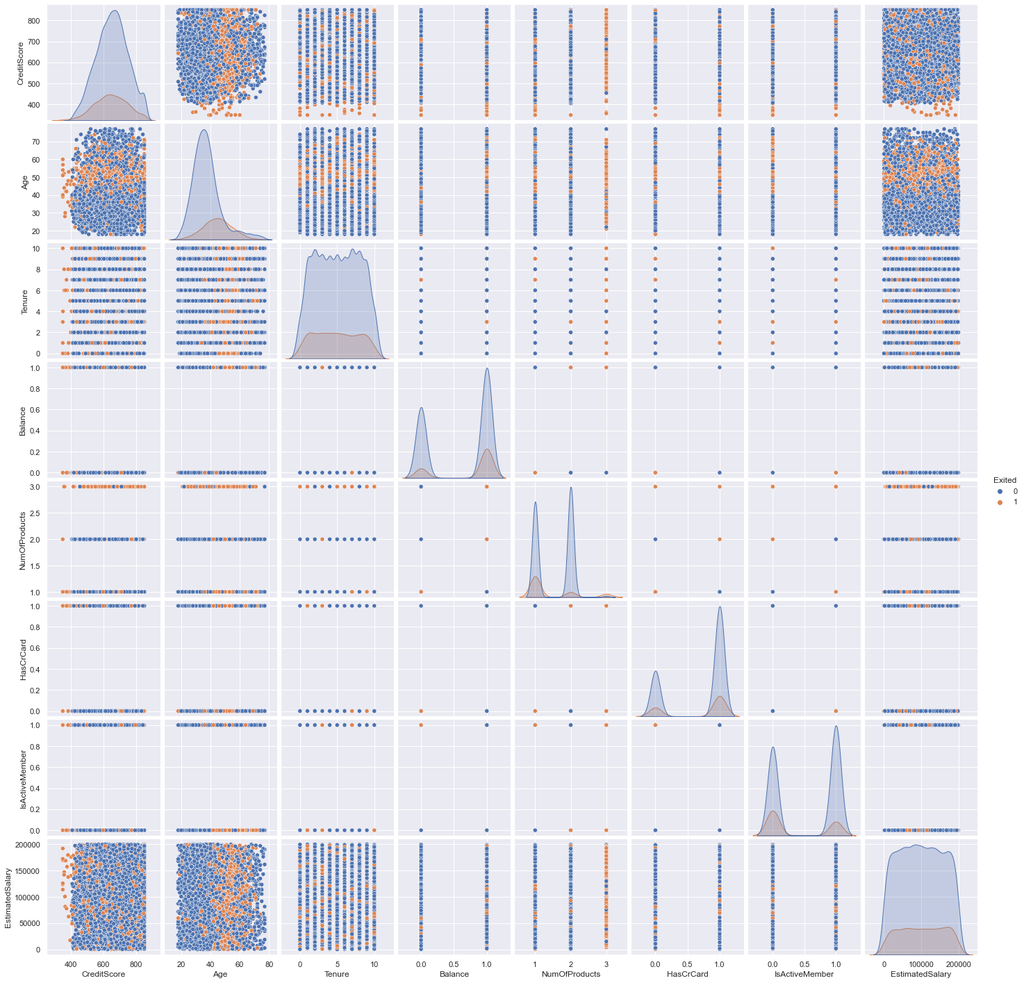

```python
sns.pairplot(bank, hue='Exited')
```

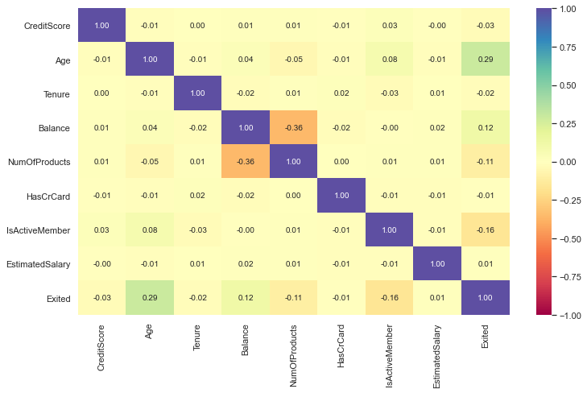

```python
# plot correlation matrix
plt.figure(figsize=(12, 7))
sns.heatmap(
    bank.corr(), annot=True, vmin=-1, vmax=1, fmt=".2f", cmap="Spectral"
)
plt.show()
```

### Pairplots and correlations observations

No significant linear correlations found between numeric variables.

##### Age vs Exited

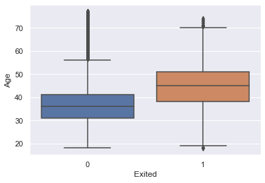

```python
sns.boxplot(y=bank["Age"], x=bank[target_class])
```

Exited customers tend to have higher age.

##### CreditScore vs Exited

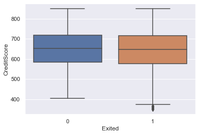

```python
sns.boxplot(y=bank["CreditScore"], x=bank[target_class])
```

There are more customers near the low end of Credit score who Exited.

##### Tenure vs Exited

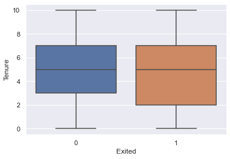

```python
sns.boxplot(y=bank["Tenure"], x=bank[target_class])
```

Exited customers have a larger IQR than non-exited customers. Median and range are the same across customers.

##### EstimatedSalary vs Exited

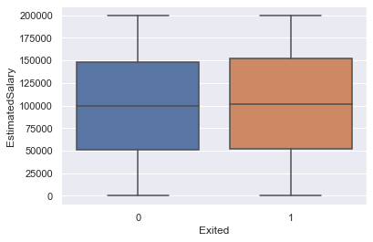

```python
sns.boxplot(y=bank["EstimatedSalary"], x=bank[target_class])
```

There are no apparent differences in the EstimatedSalary distributions between exited and non-exited customers.

##### NumOfProducts vs Exited

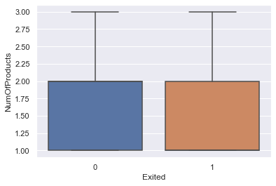

```python
sns.boxplot(y=bank["NumOfProducts"], x=bank[target_class])
```

There are no apparent differences in this plot of NumOfProducts distributions between exited and non-exited customers.

##### Balance vs Exited

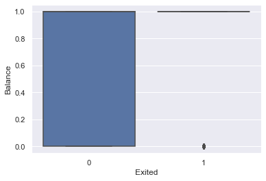

```python
sns.boxplot(y=bank["Balance"], x=bank[target_class])
```

Exited customers tend to have slightly higher Balance than non-exited

#### Bi-variate analysis for categorical variables

```python
### Function to plot stacked bar charts for categorical columns
def stacked_plot(data, x, y):
    ''' Plot stacked bar charts.
        data = dataframe,
        x = categorical column to plot across x axis
        y = categorical column to stack
    '''
    sns.set()
    ## crosstab
    tab1 = pd.crosstab(data[x],data[y],margins=True)
    print(tab1)
    print('-'*120)
    ## visualising the cross tab
    tab = pd.crosstab(data[x],data[y],normalize='index')
    tab.plot(kind='bar',stacked=True,figsize=(17,7))
    plt.legend(loc='lower left', frameon=False,)
    plt.legend(loc="upper left", bbox_to_anchor=(1,1))
    plt.show()
```

##### Geography vs Exited

```
Exited        0     1   All
Geography
France     4190   780  4970
Germany    1691   790  2481
Spain      2059   406  2465
All        7940  1976  9916
------------------------------------------------------------------------------------------------------------------------
```

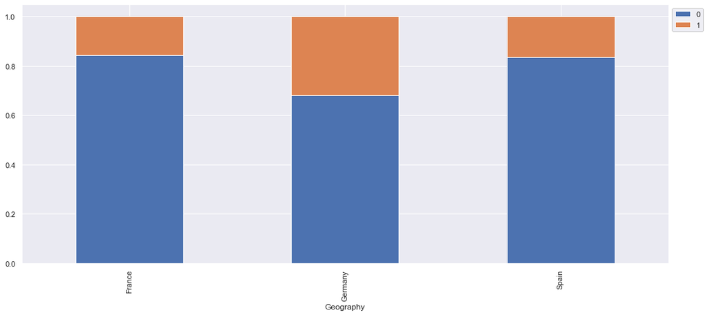

```python
stacked_plot(bank, "Geography", target_class)
```

Customers from Germany leave at higher rates than other countries.

##### Gender vs Exited

```
Exited     0     1   All
Gender
Female  3393  1100  4493
Male    4547   876  5423
All     7940  1976  9916
------------------------------------------------------------------------------------------------------------------------
```

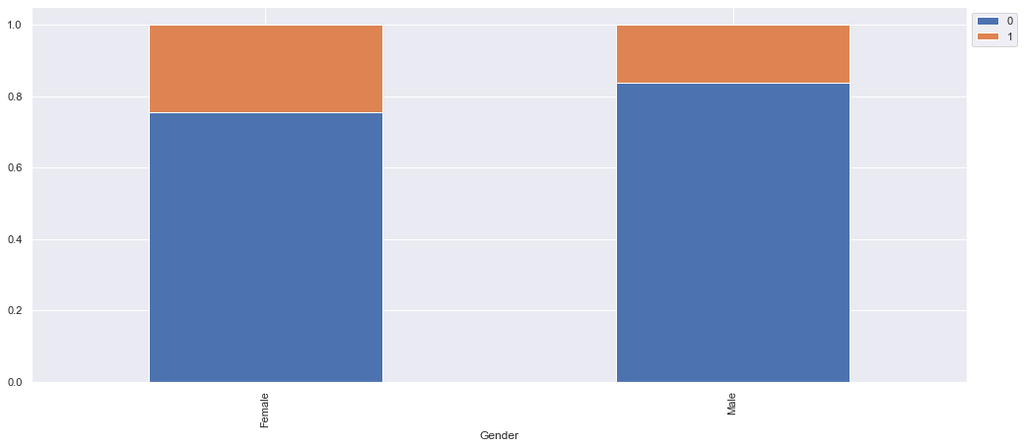

```python
stacked_plot(bank, "Gender", target_class)
```

Females leave at higher rates than Males.

##### HasCrCard vs Exited

```
Exited        0     1   All
HasCrCard
0          2325   593  2918
1          5615  1383  6998
All        7940  1976  9916
------------------------------------------------------------------------------------------------------------------------
```

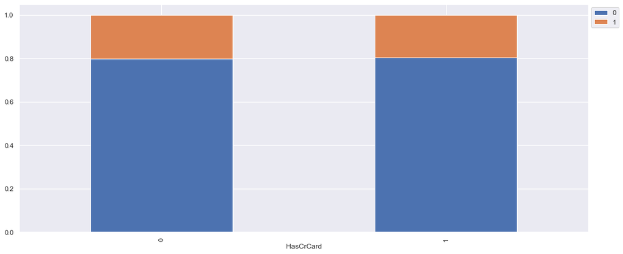

```python
stacked_plot(bank, "HasCrCard", target_class)
```

There is only a slight difference in rates of Exited between customers with or without a credit card.

##### IsActiveMember vs Exited

```
Exited             0     1   All
IsActiveMember
0               3547  1270  4817
1               4393   706  5099
All             7940  1976  9916
------------------------------------------------------------------------------------------------------------------------
```

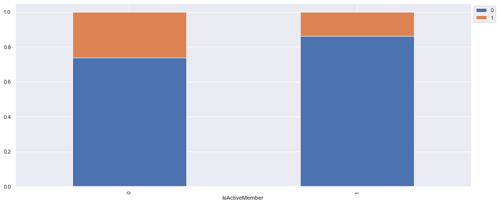

```python
stacked_plot(bank, "IsActiveMember", target_class)
```

Inactive members leave the bank at higher rates than active ones.

### Data preparation prior to modeling

Split data into train , validation and test sets

```python
from sklearn.model_selection import train_test_split

# Split target from features
X = bank.drop(target_class, axis=1)

# encode categorical variable
#X = pd.get_dummies(X)
X = pd.get_dummies(X, drop_first=True)

y = bank[target_class]
# split out test
X_intermediate, X_test, y_intermediate, y_test = train_test_split(X, y, test_size=0.2, random_state=1, stratify=y)

# split into train and validation
X_train, X_val, y_train, y_val = train_test_split(X_intermediate, y_intermediate, test_size=0.25, random_state=1, stratify=y_intermediate)

print(X_train.shape, X_val.shape, X_test.shape)
print(f'Target train class ratio: {100*(y_train[y_train == 1]).count()/len(y_train)}')
print(f'Target val class ratio: {100*(y_val[y_val == 1]).count()/len(y_val)}')
print(f'Target test class ratio: {100*(y_test[y_test == 1]).count()/len(y_test)}')
```

```
(5949, 11) (1983, 11) (1984, 11)
Target train class ratio: 19.93612371827198
Target val class ratio: 19.919314170448814
Target test class ratio: 19.909274193548388
```

```python
X.info()
```

```
<class 'pandas.core.frame.DataFrame'>
Int64Index: 9916 entries, 0 to 9999
Data columns (total 11 columns):
 #   Column             Non-Null Count  Dtype
---  ------             --------------  -----
 0   CreditScore        9916 non-null   int64
 1   Age                9916 non-null   int64
 2   Tenure             9916 non-null   int64
 3   Balance            9916 non-null   int64
 4   NumOfProducts      9916 non-null   int64
 5   HasCrCard          9916 non-null   int64
 6   IsActiveMember     9916 non-null   int64
 7   EstimatedSalary    9916 non-null   float64
 8   Geography_Germany  9916 non-null   uint8
 9   Geography_Spain    9916 non-null   uint8
 10  Gender_Male        9916 non-null   uint8
dtypes: float64(1), int64(7), uint8(3)
memory usage: 1.0 MB
```

##### Scale features

```python
from sklearn.preprocessing import StandardScaler, MinMaxScaler

# scaler = MinMaxScaler()
# models have lower performance if minmax scaler is used

scaler = StandardScaler()

scaler.fit(X_train)
X_train = scaler.transform(X_train)
X_val = scaler.transform(X_val)
X_test = scaler.transform(X_test)
```

```python
print(np.mean(X_train, axis=0))
print(np.mean(X_val, axis=0))
print(np.mean(X_test, axis=0))
```

```
[ 2.57988285e-16  7.10662175e-17  1.67214629e-17  1.73186580e-17
 -1.38549264e-16 -2.38878042e-17  7.50972844e-17  2.01254750e-16
  3.94148769e-17  1.19439021e-17  6.21082909e-17]
[ 0.02829322 -0.02146811 -0.00994309 -0.05066641  0.04213599  0.00884623
 -0.0094163  -0.01358811  0.01631263 -0.00194637 -0.03954623]
[ 0.00823342  0.02703946 -0.01467768 -0.05026898  0.04439829 -0.00077917
  0.02637334  0.01151363 -0.00960751  0.00943755 -0.00866709]
```

### Model training and evaluation

#### Model evaluation criteria

When classifying we have False Positive and False Negative errors.

- False Positive = we predict a customer will leave but the customer doesn't.  
  This might result in effort wasted on retaining customers who were not planning on leaving.
- False Negative = we predict a customer will not leave but the customer does.  
  This is a lost opportunity to retain a customer with corresponding revenue loss.

For this classification we want to reduce the number of false negatives.

We will use AUC score to evaluate the model overall and also consider Recall.

##### Sanity check with traditional ML algorithm

###### Function to plot confusion matrix

```python
def plot_confusion_matrix(model, X, y_actual, threshold=0.5):
    '''Plot confusion matrix from model, X and y_actual.
    '''
    if hasattr(model, 'predict_proba') and callable(getattr(model, 'predict_proba')):
        y_predict = (model.predict_proba(X)[:,1] > threshold) * 1
    else:
        y_predict = (model.predict(X) > threshold) * 1

    cm = metrics.confusion_matrix(y_actual, y_predict)
    # print(cm.flatten())
    # https://scikit-learn.org/stable/modules/generated/sklearn.metrics.confusion_matrix.html
    TN = cm[0,0]
    FP = cm[0,1]
    FN = cm[1,0]
    TP = cm[1,1]
    # print(f'TN:{TN}, FN:{FN}, TP:{TP}, FP:{FP}')
    accuracy  = (TP + TN) / (TN+FN+TP+FP)
    precision = TP / (TP + FP)
    recall    = TP / (TP + FN)
    f1_score  = 2 * precision * recall / (precision + recall)
    scores = "\nAccuracy={:0.3f} - Precision={:0.3f} - Recall={:0.3f} - F1 Score={:0.3f}".format(accuracy,precision,recall,f1_score)
    df_cm = pd.DataFrame(cm, index = [i for i in ["0","1"]],
                  columns = [i for i in ["Predict 0","Predict 1"]])
    group_names = ['TN', 'FP','FN','TP']
    group_counts = ["{0:0.0f}".format(value) for value in
                cm.flatten()]
    group_percentages = ["{0:.2%}".format(value) for value in
                     cm.flatten()/np.sum(cm)]
    labels = [f"{v1}\n{v2}\n{v3}" for v1, v2, v3 in
          zip(group_names,group_counts,group_percentages)]
    labels = np.asarray(labels).reshape(2,2)

    plt.figure(figsize=(5,3))
    sns.heatmap(df_cm, annot=labels, fmt='', cmap='Spectral')
    print(scores)
    return accuracy, precision, recall, f1_score
```

###### Function to plot ROC-AUC curves

```python
from sklearn.metrics import roc_curve
from sklearn.metrics import roc_auc_score
from sklearn.metrics import plot_precision_recall_curve

def plot_roc_auc(classifier, x, y):
    if hasattr(classifier, 'predict_proba') and callable(getattr(classifier, 'predict_proba')):
        predict_prob = classifier.predict_proba(x)[:,1]
    else:
        predict_prob = classifier.predict(x)

    zero_predict = np.zeros(y.shape[0])
    # get auc score
    ns_auc = roc_auc_score(y, zero_predict)
    nn_auc = roc_auc_score(y, predict_prob)
    # summarize scores
    print('No Skill: ROC AUC=%.3f' % (ns_auc))
    print('Model: ROC AUC=%.3f' % (nn_auc))
    # calculate roc curves
    ns_fpr, ns_tpr, _ = roc_curve(y, zero_predict)
    nn_fpr, nn_tpr, _ = roc_curve(y, predict_prob)
    # plot the roc curve for the model
    plt.figure(figsize=(6,6))
    plt.plot(ns_fpr, ns_tpr, linestyle='--', label='No Skill')
    plt.plot(nn_fpr, nn_tpr, marker='.', label='NN')
    # axis labels
    plt.xlabel('False Positive Rate')
    plt.ylabel('True Positive Rate')
    # show the legend
    plt.legend()
    # show the plot
    plt.show()

    # precision/recall curve
    prec, rec, thr = metrics.precision_recall_curve(y, predict_prob)

    # find optimal threshold : min of difference between rec and prec
    pr_diff = np.abs(rec-prec)
    optimal_threshold = thr[np.argmin(pr_diff)]
    # get recall score using the optimal threshold
    predict_optimal_threshold = (predict_prob > optimal_threshold ) * 1
    recall_for_optimal_threshold = metrics.recall_score(y, predict_optimal_threshold)

    # Plot threshold vs Precision/Recall
    fig = plt.figure(figsize=(10,5))
    ax = fig.add_subplot(1, 1, 1)
    ax.plot(thr, prec[:-1], 'b--', label='precision')
    ax.plot(thr, rec[:-1], 'g--', label = 'recall')
    plt.xlabel('Threshold')
    plt.legend(loc='lower left')
    plt.ylim([0,1])
    ax.set_xticks(np.arange(0,1.05,0.05))
    ax.grid(markevery=10, which='major')
    plt.show()

    return nn_auc, optimal_threshold, recall_for_optimal_threshold
```

```python
def plot_model_metrics(modl, x, y):
    modl.evaluate(x, y)
    accuracy, precision, recall, f1_score = plot_confusion_matrix(modl, x, y)
    plt.show()
    auc_score, optimal_threshold, recall_opt_thr = plot_roc_auc(modl, x, y)
    return auc_score, accuracy, precision, recall, f1_score, optimal_threshold, recall_opt_thr
```

```python
from xgboost import XGBClassifier
from sklearn.model_selection import train_test_split, GridSearchCV, RandomizedSearchCV, StratifiedKFold, cross_val_score

models = [] # holds models to be trained
model_names = []
cv_scores = []  # holds cross-validation score for each model
val_scores = []  # validation set score

# models.append(('Decision Tree', DecisionTreeClassifier(random_state=1)))
# models.append(('Random Forest', RandomForestClassifier(random_state=1)))
# models.append(('Adaboost', AdaBoostClassifier(random_state=1)))
# models.append(('Gradient Boost', GradientBoostingClassifier(random_state=1)))
# models.append(('Logistic Reg', LogisticRegression(random_state=1)))
models.append(('XGBoost', XGBClassifier(random_state=1, eval_metric='logloss', use_label_encoder=False)))

# Use recall to evaluate model metrics
scorer = metrics.make_scorer(metrics.recall_score)
splits = 5  # cross-validation folds

kfold = StratifiedKFold(n_splits=splits, random_state=1, shuffle=True)

def run_ml_models(x,y,xval,yval):
    model_names = []
    cv_scores = []  # holds cross-validation score for each model
    val_scores = []  # validation set score

    for name, clf in models:
        model_names.append(name)
        print('Model name:', name,'\n===========')
        score = cross_val_score(estimator=clf, X=x, y=y, scoring=scorer, cv=kfold)
        cv_scores.append(score)
        print('> Avg. Score:(train)',round(np.mean(score),5), 'CV scores:',score,)
        clf.fit(x, y)

        val_score = metrics.recall_score(yval, clf.predict(xval))
        val_scores.append(val_score)
        print('> Validation recall:', round(val_score,5))

        print('\nConfusion matrix: train set')
        plot_confusion_matrix(clf, x, y)
        plt.show()
        print('\nConfusion matrix: validation set')
        plot_confusion_matrix(clf, xval, yval)
        plt.show()

        plot_roc_auc(clf, xval, yval)
```

```
Model name: XGBoost
===========
> Avg. Score:(train) 0.44097 CV scores: [0.40506329 0.4556962  0.43037975 0.44537815 0.46835443]
> Validation recall: 0.46076

Confusion matrix: train set

Accuracy=0.955 - Precision=0.971 - Recall=0.799 - F1 Score=0.877
```

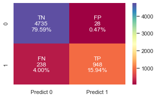

```
Confusion matrix: validation set

Accuracy=0.857 - Precision=0.719 - Recall=0.461 - F1 Score=0.562
```

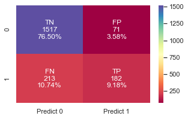

```
No Skill: ROC AUC=0.500
Model: ROC AUC=0.848
```

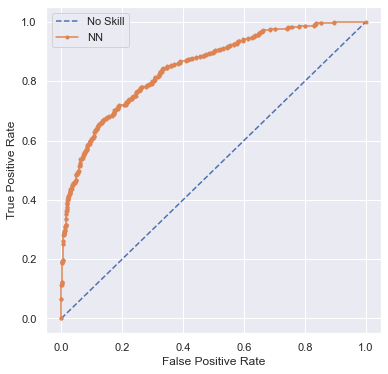

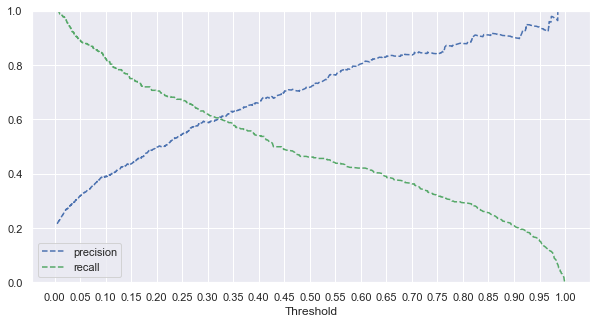

```
Wall time: 3.89 s
```

```python
%%time
run_ml_models(X_train,y_train,X_val,y_val)
```

Performance of the model is low with recall less than 50% against validation sets.

Also the model is overfit (more than 30% difference between train and validation scores)